# Simulation experiment (2)

## Design of the experiment

Same as experiment 1. In this experiment we focus on the effect of the structural noise in the reference method that is not explained by the non-reference method ($\sigma_y$) and the correlation between the measurement error of both methods ($\rho$). Other parameter values are kept fixed:

Table: Parameter values for the scenario’s of experiment 2.

| Parameter | Values |
| --- | --- |
| $N$ | 200 |
| $\mu_x$ | 0 |
| $\sigma_x$ | 1 |
| $\alpha$ | 0 |
| $\beta$ | 1 |
| $\sigma_y$ | 0.01, 0.1, 0.2 |
| Tails measurement error | Normal distribution |
| $\tau_x$ | 0.1 |
| $\tau_{xy}$ | 1 |
| $\rho$ | 0, 0.5, 0.9 |

## Description of the models

Same as in experiment 1:

- linear regression
- EIV-regression with known SD of measurement error
- EIV-regression with prior on SD of measurement error

## Evaluation of the models

Same as in experiment 1: a validation dataset of $N$ = 1000 observations are sampled from the same data-generating mechanism as the training dataset and the fitted models are used to make predictions. The predictions are compared with the simulated validation data.

## Results

Figure 1 displays the results in function of the correlation of the measurement errors and Figure 2 displays the results in function of the structural error in the reference method. Figure 3 displays the results in function of the realized regression dilution.

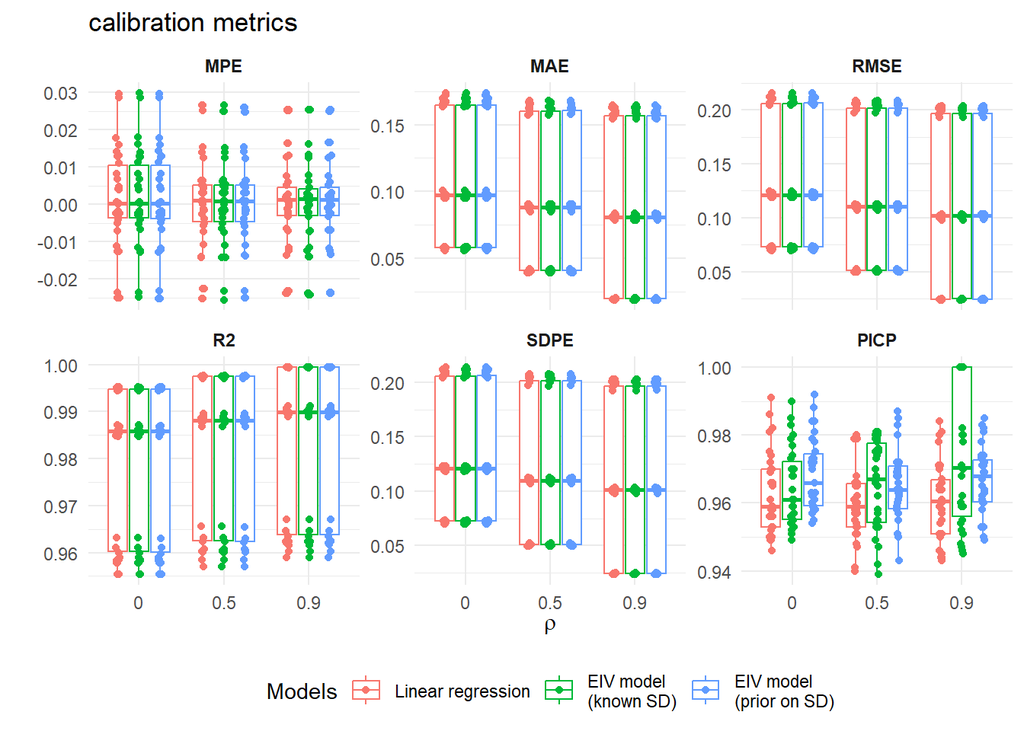

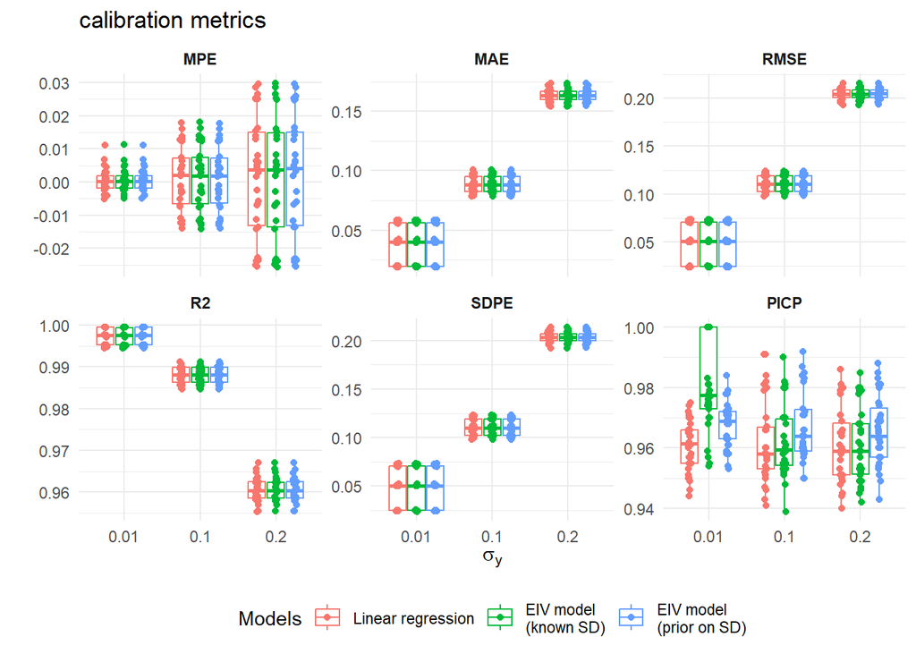

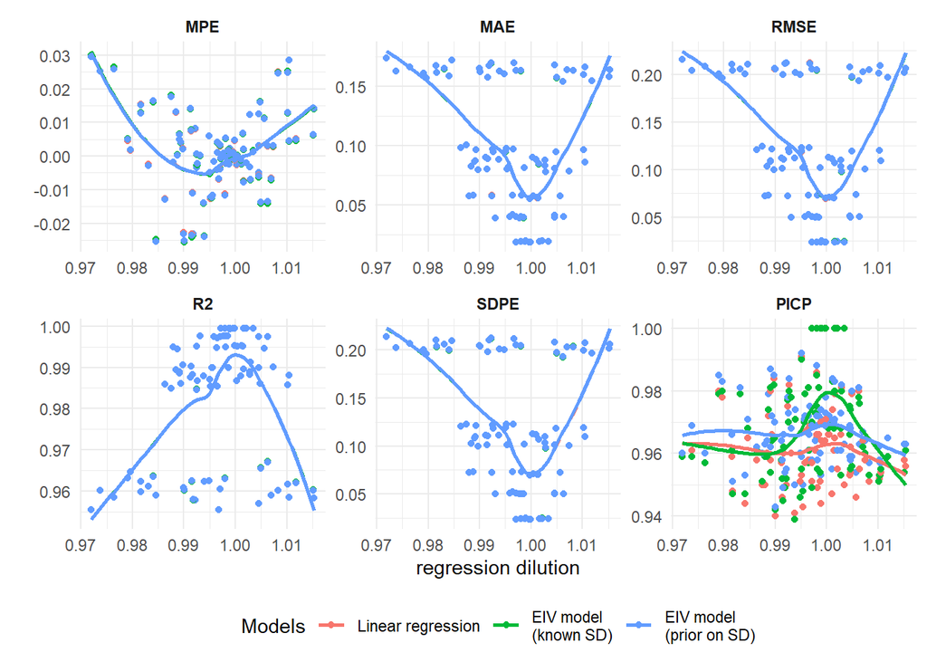

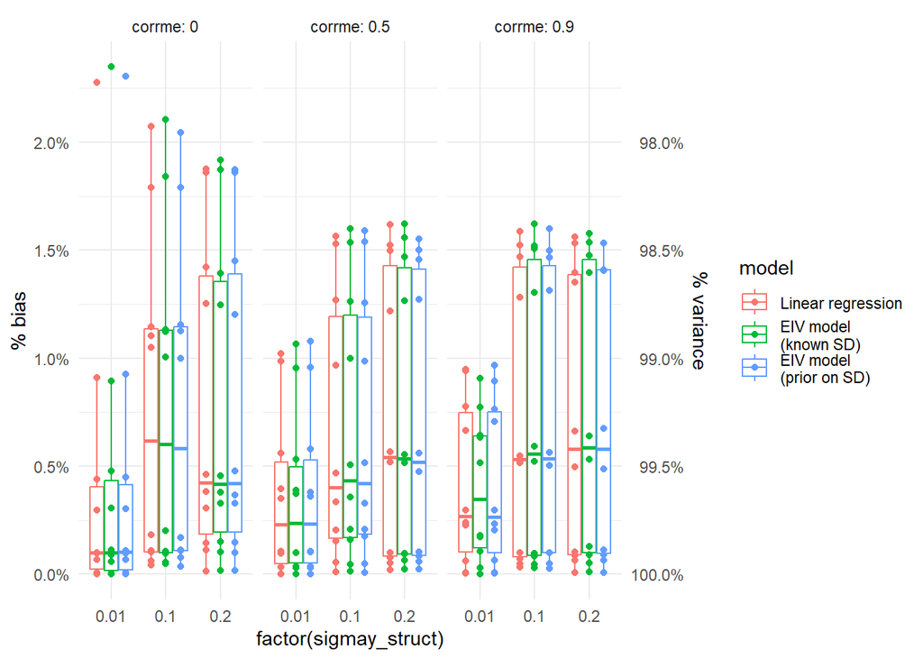

Figure 4: Results of the simulation experiment: %bias and %variance

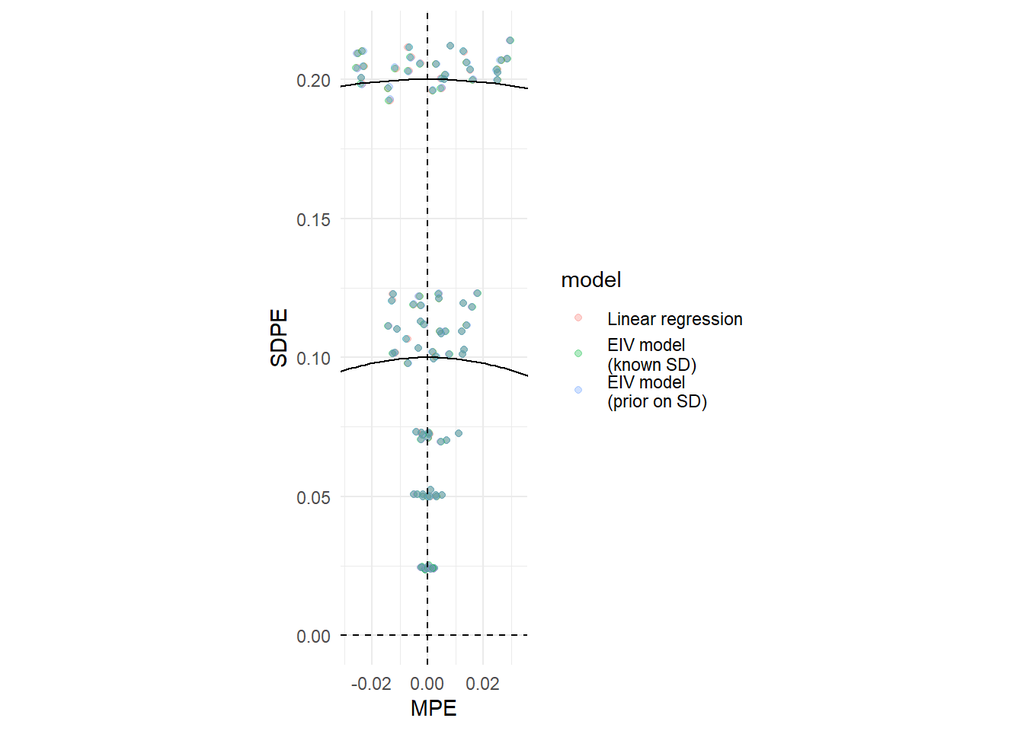

Figure 5: Results of the simulation experiment: MPE vs. SDPE. All points on the circles have the same RMSE. Aggregated across sigma_y and corr_me

The following figure display the $\hat{R}$ statistic of the MCMC for each of the model parameters. The red dashed lines are at 1.00 and 1.01. The boxplots are aggregated across scenario’s because the values were similar in each of them and all well below 1.01.

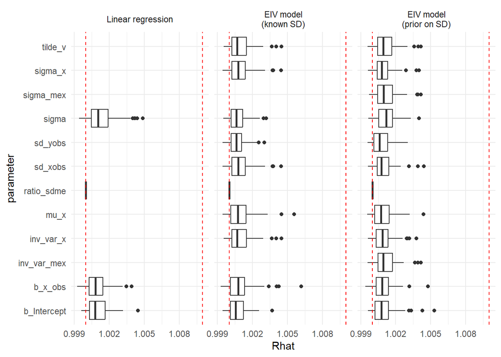